# AMS 572 Final Project

Branden Ciranni & Ashler Herrick

December 01, 2020

# Analysis of Diabetes Data

```r
# Library Requirements - Separate file to keep things neat.
source("libraries.R")

# Utility Functions, in separate script for neatness
source("utilities.R")

data <- read.csv("./data/diabetes.csv", header = TRUE)
head(data)
```

```
##     id chol stab.glu hdl ratio glyhb   location age gender height weight  frame
## 1 1000  203       82  56   3.6  4.31 Buckingham  46 female     62    121 medium
## 2 1001  165       97  24   6.9  4.44 Buckingham  29 female     64    218  large
## 3 1002  228       92  37   6.2  4.64 Buckingham  58 female     61    256  large
## 4 1003   78       93  12   6.5  4.63 Buckingham  67   male     67    119  large
## 5 1005  249       90  28   8.9  7.72 Buckingham  64   male     68    183 medium
## 6 1008  248       94  69   3.6  4.81 Buckingham  34   male     71    190  large
##   bp.1s bp.1d bp.2s bp.2d waist hip time.ppn
## 1   118    59    NA    NA    29  38      720
## 2   112    68    NA    NA    46  48      360
## 3   190    92   185    92    49  57      180
## 4   110    50    NA    NA    33  38      480
## 5   138    80    NA    NA    44  41      300
## 6   132    86    NA    NA    36  42      195
```

```r
unique(data$location)
```

```
## [1] "Buckingham" "Louisa"
```

We add an additonal field to this data for classification purposes. It is taken as a diagnosis of diabetes if the "Glycosated Hemoglobin" measurement `glyhb >= 7.0`. This will be assumed to be the case for this analysis.

We also add the ratio `waist_hip_ratio` = $\frac{waist}{hip}$.

```r
data <- transform(data, has_diabetes = glyhb >= 7.0, wh_ratio = waist/hip)
```

```r
data %>% group_by(has_diabetes) %>%
          count()
```

```
## # A tibble: 3 x 2
## # Groups:   has_diabetes [3]
##   has_diabetes     n
##   <lgl>        <int>
## 1 FALSE          330
## 2 TRUE            60
## 3 NA              13
```

### Diabetes vs Not Diabetes

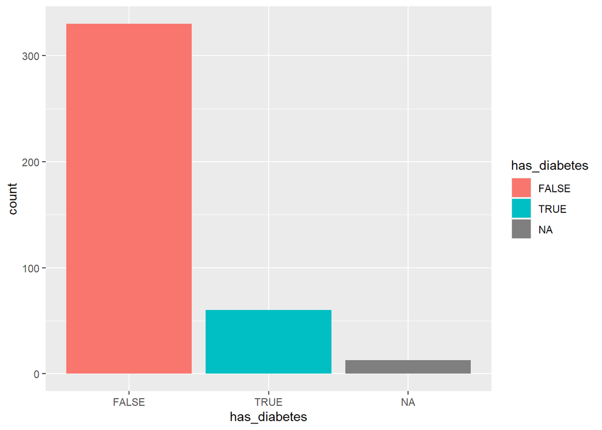

```r
ggplot(data, aes(x=has_diabetes)) +
  geom_bar(aes(fill=has_diabetes))
```

We observe that we have an unbalanced dataset, with far more study participants that are testing negative for diabetes, than positive. We will drop the rows which have null values for the diabetes classification.

### Analysis of Null Values

```r
# First, mutate dataframe to change empty strings to NA
data <- data %>% mutate_if(is.character, list(~na_if(.,"")))

# Then, use the count_null function in our utilities script
count_null(data)
```

```
##                   feature null.count   null.perc
## bp.2s               bp.2s        262 0.650124069
## bp.2d               bp.2d        262 0.650124069
## glyhb               glyhb         13 0.032258065
## has_diabetes has_diabetes         13 0.032258065
## frame               frame         12 0.029776675
## height             height          5 0.012406948
## bp.1s               bp.1s          5 0.012406948
## bp.1d               bp.1d          5 0.012406948
## time.ppn         time.ppn          3 0.007444169
## waist               waist          2 0.004962779
## hip                   hip          2 0.004962779
## wh_ratio         wh_ratio          2 0.004962779
## chol                 chol          1 0.002481390
## hdl                   hdl          1 0.002481390
## ratio               ratio          1 0.002481390
## weight             weight          1 0.002481390
## id                     id          0 0.000000000
## stab.glu         stab.glu          0 0.000000000
## location         location          0 0.000000000
## age                   age          0 0.000000000
## gender             gender          0 0.000000000
```

We observe that there are a large number of null values in the `bp.2s` and `bp.2d` columns. We otherwise see a very low number of null values. We can discard these two columns given that $65\%$ of the data does not have values.

```r
data <- data %>% dplyr::select(-c('bp.2s', 'bp.2d'))
```

Because Our Analysis Will focus on the indicators of diabetes, we will exclude those rows which have null values for `glyhb`, and thus, our indicator variable `has_diabetes`.

```r
data <- filter(data, !is.na(has_diabetes))
```

### Plot all Numeric Variables for Data Exploration

#### Box Plots

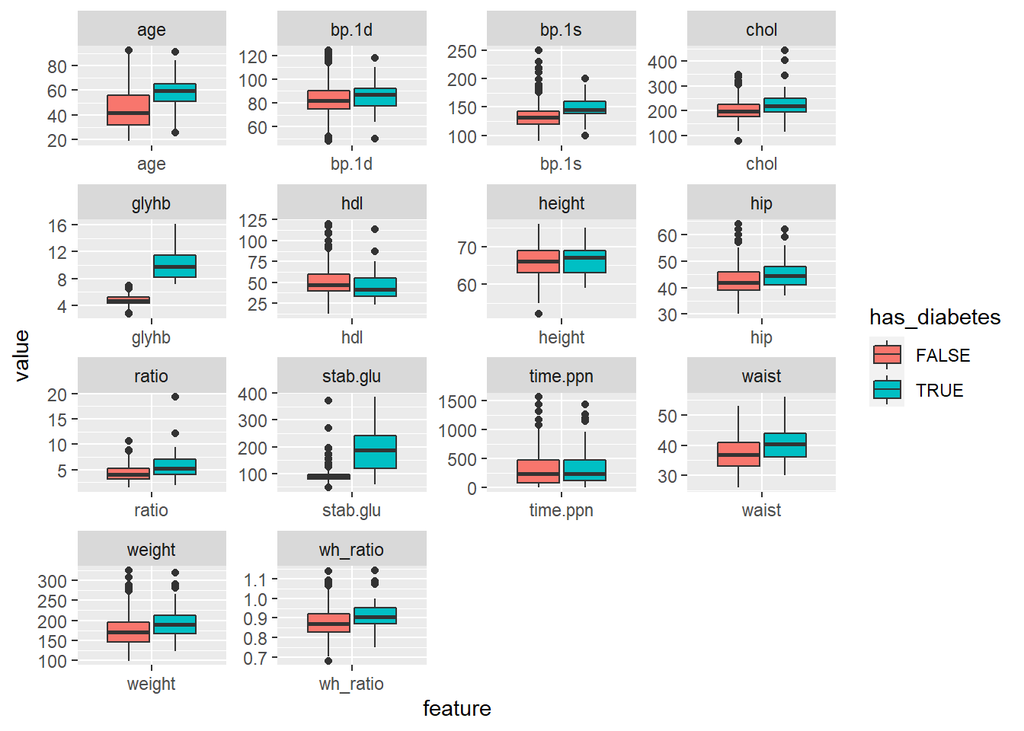

```r
data %>%
  dplyr::select(-c("id", "location", "gender", "frame")) %>%
  gather(key="feature", value="value", -has_diabetes) %>%
  ggplot(aes(x=feature, y=value, fill=has_diabetes)) +
    facet_wrap(~ feature, scales = "free") +
    geom_boxplot()
```

#### Histogram / Density Plots

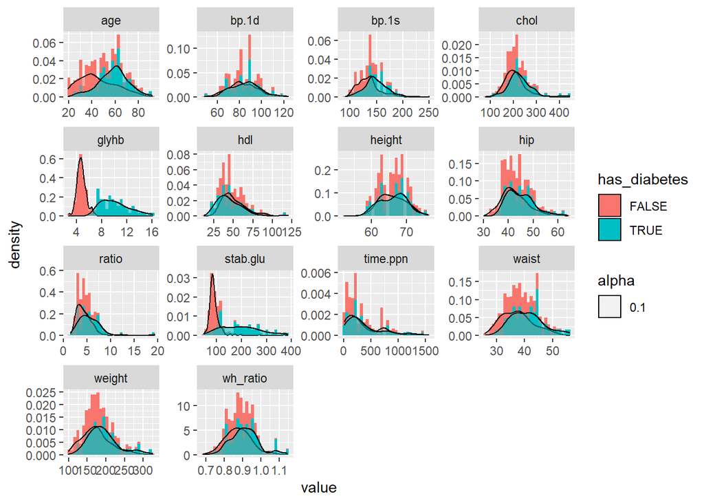

```r
data %>%
  dplyr::select(-c("id", "location", "gender", "frame")) %>%
  gather(key="feature", value="value", -has_diabetes) %>%
  ggplot(aes(value)) +
    facet_wrap(~ feature, scales = "free") +
    geom_histogram(aes(y=..density.., fill=has_diabetes)) +
    geom_density(aes(y=..density.., fill=has_diabetes, alpha=0.1))
```

We see that some features in our data are clearly not normally distributed. We will need to take this into account in future analyses. However, there do appear to be several natural hypotheses to test. Variables that have a significant shift in the center of the distribution are:  
- `age`  
- `stab.glu`  
- `waist`  
- `weight`  
- `wh_ratio`

Because we are not doing any sort of analysis on `glyhb` and are rather using `glyhb > 7.0` as an indicator variable, we do not have to do any sort of transform, but a log or sqrt transform could make it behave more normally.

```r
# Use our Utility function in `utilities.R` to map the categorical, but ordinal string values to
# numerical integer values so we may include them in the correlation analysis
data$frame <- cat_to_ord(data, "frame", c("small", "medium", "large"))
```

The new Unique values are shown here:

```r
unique(data$frame)
```

```
## [1]  2  3  1 NA
```

### Waist Hip Ratio, segmented by Diabetes Diagnosis

Analyze the effect of `wh_ratio` on Diabetes Diagnosis.

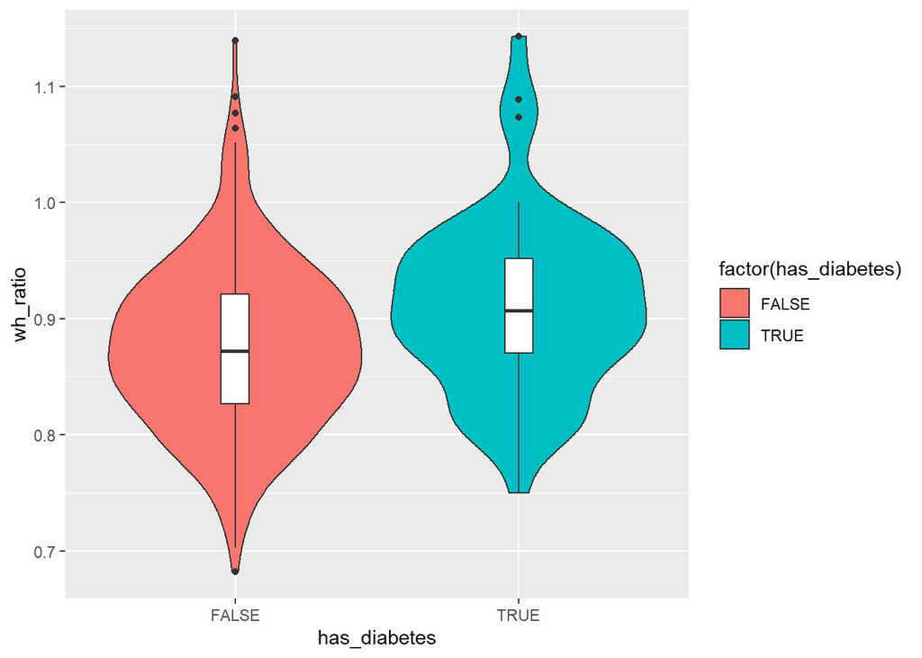

```r
ggplot(data, aes(x=has_diabetes, y=wh_ratio)) +
  geom_violin(aes(fill=factor(has_diabetes))) +
  geom_boxplot(width=0.1)
```

The violin & box plot suggest that the mean waist hip ratio is likely to be greater in participants with diabetes.

```r
wh_data <- data %>%
            filter(!is.na(wh_ratio)) %>%
            group_by(has_diabetes) %>%
            summarize(mean = mean(wh_ratio),
                      var = var(wh_ratio),
                      n = n())
wh_data
```

```
## # A tibble: 2 x 4
##   has_diabetes  mean     var     n
##   <lgl>        <dbl>   <dbl> <int>
## 1 FALSE        0.875 0.00512   328
## 2 TRUE         0.911 0.00571    60
```

Use a T-test to test whether there is a significant difference between the means, and an F-test to test the equal variance assumption.

First, the data is prepared.

```r
diabetes_pos <- data %>% filter(has_diabetes)
diabetes_neg <- data %>% filter(!has_diabetes)

wh_pos <- diabetes_pos$wh_ratio
wh_neg <- diabetes_neg$wh_ratio
```

#### Test for Normality

Testing the data corresponding to positive diabetes test (`has_diabetes = TRUE`) at $\alpha = 0.05$.

```r
shapiro.test(wh_pos)
```

```
##
##  Shapiro-Wilk normality test
##
## data:  wh_pos
## W = 0.96358, p-value = 0.0705
```

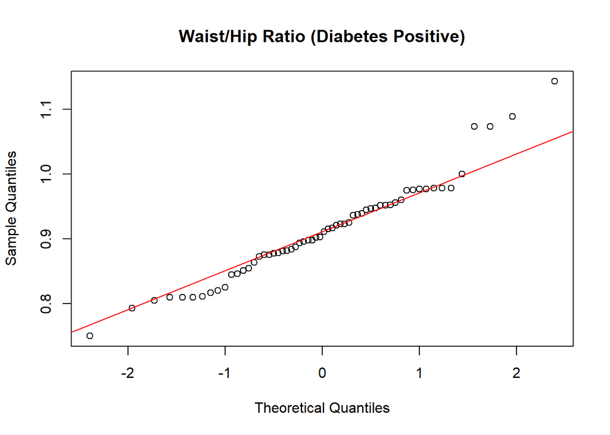

```r
qqnorm(wh_pos, main="Waist/Hip Ratio (Diabetes Positive)")
qqline(wh_pos, col='red')
```

We see $p > 0.05$, thus we cannot reject the normality assumption.

Testing the data corresponding to negative diabetes test. (`has_diabetes = FALSE`) at $\alpha = 0.05$.

```r
shapiro.test(wh_neg)
```

```
##
##  Shapiro-Wilk normality test
##
## data:  wh_neg
## W = 0.99181, p-value = 0.06691
```

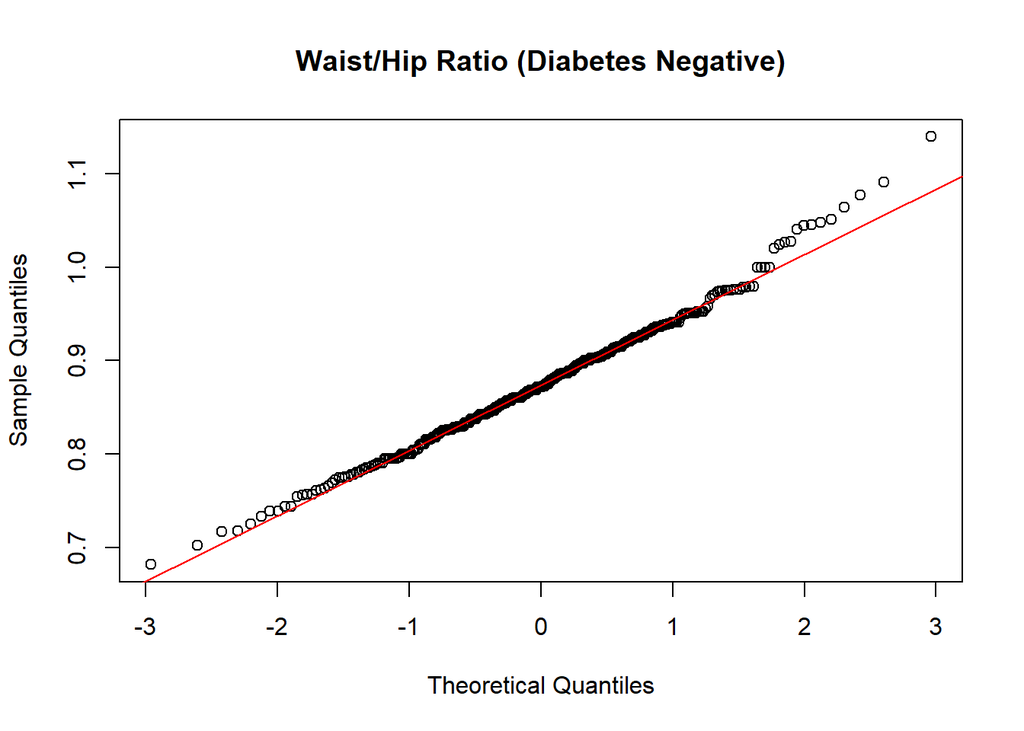

```r
qqnorm(wh_neg, main="Waist/Hip Ratio (Diabetes Negative)")
qqline(wh_neg, col='red')
```

Likewise, we see $p > 0.05$, and cannot reject the normality assumption. By the above Shapiro-Wilk Tests, we can assume normality in the data with $95\%$ confidence.

First, we test the equal variance assumption with an F Test.

```r
var.test(wh_pos, wh_neg, alternative = "two.sided")
```

```
##
##  F test to compare two variances
##
## data:  wh_pos and wh_neg
## F = 1.1148, num df = 59, denom df = 327, p-value = 0.5516
## alternative hypothesis: true ratio of variances is not equal to 1
## 95 percent confidence interval:
##  0.7717174 1.7007293
## sample estimates:
## ratio of variances
##           1.114773
```

Since $p > 0.05$, we can assume equal variances. Then the t-test gives us:

```r
t.test(wh_pos, wh_neg, var.equal = TRUE)
```

```
##
##  Two Sample t-test
##
## data:  wh_pos and wh_neg
## t = 3.5464, df = 386, p-value = 0.0004385
## alternative hypothesis: true difference in means is not equal to 0
## 95 percent confidence interval:
##  0.01601855 0.05587835
## sample estimates:
## mean of x mean of y
## 0.9113142 0.8753658
```

Thus, since $p < 0.05$, there is a statistically significant difference between the waist hip ratio in participants with diabetes and without diabetes.

### Calculate Kendall's Correlation Coefficient between all variables

We see above in the data exploration that some variables have a very large variance, while others have a much tighter distribution. The best example of this is stabilized glucose, `stab.glu`, which shows a large number of outliers in participants without diabetes.

Additionally, the data is not guaranteed to be normal.

As Kendall's coefficient is less sensitive to outliers and does not require normality or equality of variance, we use it over Pearson's.

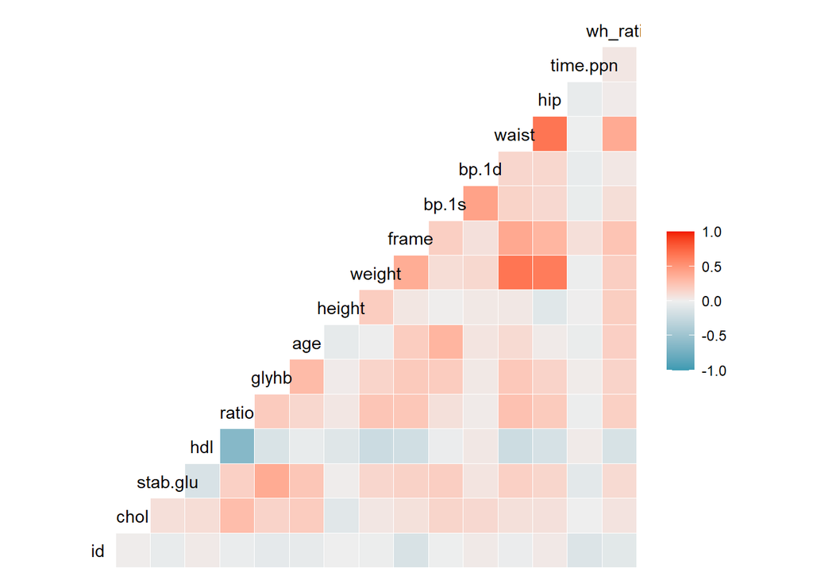

```r
ggcorr(data, method = c("pairwise", "kendall"))
```

We see the strongest correlations between obviously correlated features such as waist, weight, and hip. We also see a moderate correlation between the Stabilized Glucose Level and Glycosated Hemoglobin Level, our indicator for diabetes. We also notice a somewhat positive correlation to `glyhb` for other factors above.

Let us examine some interesting features more closely, colored by diabetes diagnosis:

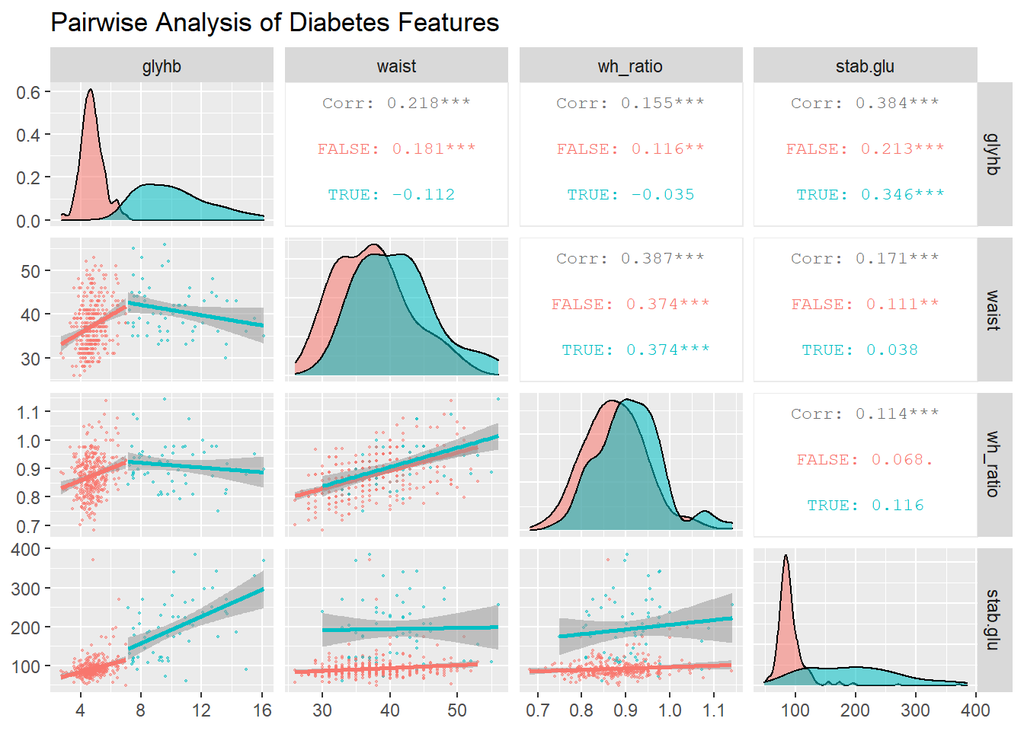

```r
ggpairs(data,
        columns = c("glyhb", "waist", "wh_ratio", "stab.glu"),
        title = "Pairwise Analysis of Diabetes Features",
        upper = list(continuous = wrap("cor", method = 'kendall', size = 3)),
        lower = list(continuous = wrap("smooth", alpha = 0.5, size = 0.3)),
        mapping = aes(color = has_diabetes, alpha=0.5))
```

## Stepwise Logistic Regression to find the best predictors

```r
data$weight_height_ratio <- with(data, weight/height)
set.seed(123)
dt = sort(sample(nrow(data), nrow(data)*.7))
train<-data[dt,]
test<-data[-dt,]
no.na.train <- na.omit(train)
no.na.test <- na.omit(test)
logistic_model <- glm(has_diabetes ~ stab.glu + chol + hdl + weight_height_ratio + wh_ratio + age,data = no.na.train, family = binomial) %>%
  stepAIC(trace = TRUE, direction = 'backward')
```

```
## Start:  AIC=106.78
## has_diabetes ~ stab.glu + chol + hdl + weight_height_ratio +
##     wh_ratio + age
##
##                       Df Deviance    AIC
## - wh_ratio             1   92.778 104.78
## - hdl                  1   92.957 104.96
## - weight_height_ratio  1   94.515 106.52
## <none>                     92.776 106.78
## - chol                 1   95.389 107.39
## - age                  1  101.027 113.03
## - stab.glu             1  170.408 182.41
##
## Step:  AIC=104.78
## has_diabetes ~ stab.glu + chol + hdl + weight_height_ratio +
##     age
##
##                       Df Deviance    AIC
## - hdl                  1   92.958 102.96
## - weight_height_ratio  1   94.601 104.60
## <none>                     92.778 104.78
## - chol                 1   95.394 105.39
## - age                  1  101.480 111.48
## - stab.glu             1  170.457 180.46
##
## Step:  AIC=102.96
## has_diabetes ~ stab.glu + chol + weight_height_ratio + age
##
##                       Df Deviance    AIC
## <none>                     92.958 102.96
## - weight_height_ratio  1   95.296 103.30
## - chol                 1   95.436 103.44
## - age                  1  101.585 109.58
## - stab.glu             1  181.186 189.19
```

```r
summary(logistic_model)
```

```
##
## Call:
## glm(formula = has_diabetes ~ stab.glu + chol + weight_height_ratio +
##     age, family = binomial, data = no.na.train)
##
## Deviance Residuals:
##      Min        1Q    Median        3Q       Max
## -2.56249  -0.29409  -0.16656  -0.08039   2.54801
##
## Coefficients:
##                       Estimate Std. Error z value Pr(>|z|)
## (Intercept)         -14.660760   2.790284  -5.254 1.49e-07 ***
## stab.glu              0.047994   0.008521   5.632 1.78e-08 ***
## chol                  0.010199   0.006887   1.481  0.13865
## weight_height_ratio   0.727723   0.466626   1.560  0.11887
## age                   0.056448   0.019964   2.827  0.00469 **
## ---
## Signif. codes:  0 '***' 0.001 '**' 0.01 '*' 0.05 '.' 0.1 ' ' 1
##
## (Dispersion parameter for binomial family taken to be 1)
##
##     Null deviance: 222.239  on 256  degrees of freedom
## Residual deviance:  92.958  on 252  degrees of freedom
## AIC: 102.96
##
## Number of Fisher Scoring iterations: 7
```

We can calculate the variance inflation factor, or VIF, to measure the multicollinearity of each predictor. VIF is bounded below by one and unbounded above.

```r
vif(logistic_model)
```

```
##            stab.glu                chol weight_height_ratio                 age
##            1.081008            1.087348            1.147157            1.158771
```

The stepwise logistic regression with the missing values removed finds that the best model is has the predictors stable glucose, cholesterol, weight/height ratio and age.

```r
exp(coef(logistic_model))
```

```
##         (Intercept)            stab.glu                chol weight_height_ratio
##        4.294500e-07        1.049164e+00        1.010251e+00        2.070362e+00
##                 age
##        1.058071e+00
```

```r
probabilities <- logistic_model %>% predict(no.na.test, type = "response")
head(probabilities)
```

```
##           1           3           6          12          15          17
## 0.009584129 0.169115222 0.022903288 0.150196347 0.006041578 0.030910455
```

```r
predicted.classes <- ifelse(probabilities > 0.10, TRUE, FALSE)
head(predicted.classes)
```

```
##     1     3     6    12    15    17
## FALSE  TRUE FALSE  TRUE FALSE FALSE
```

```r
mean(predicted.classes == no.na.test$has_diabetes)
```

```
## [1] 0.7981651
```

```r
mean(predicted.classes == no.na.test$has_diabetes & no.na.test$has_diabetes == TRUE)/mean(no.na.test$has_diabetes == TRUE)
```

```
## [1] 0.875
```

The first number is the overall classification rate of the model, and the second number is the observed power of the classifier i.e. the proportion of case in which the model identified diabetes, given diabetes was present. The probability of a type two error, or false negative, is one minus the power of the test.

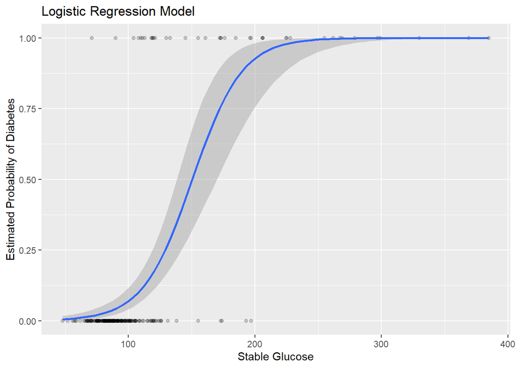

```r
no.na.train %>%
  mutate(prob = ifelse(has_diabetes == TRUE,1,0)) %>%
  ggplot(aes(stab.glu,prob)) +
  geom_point(alpha =0.2) +
  geom_smooth(method = "glm", method.args = list(family = "binomial")) +
  labs(
    title = "Logistic Regression Model",
    x = "Stable Glucose",
    y = "Estimated Probability of Diabetes"
  )
```

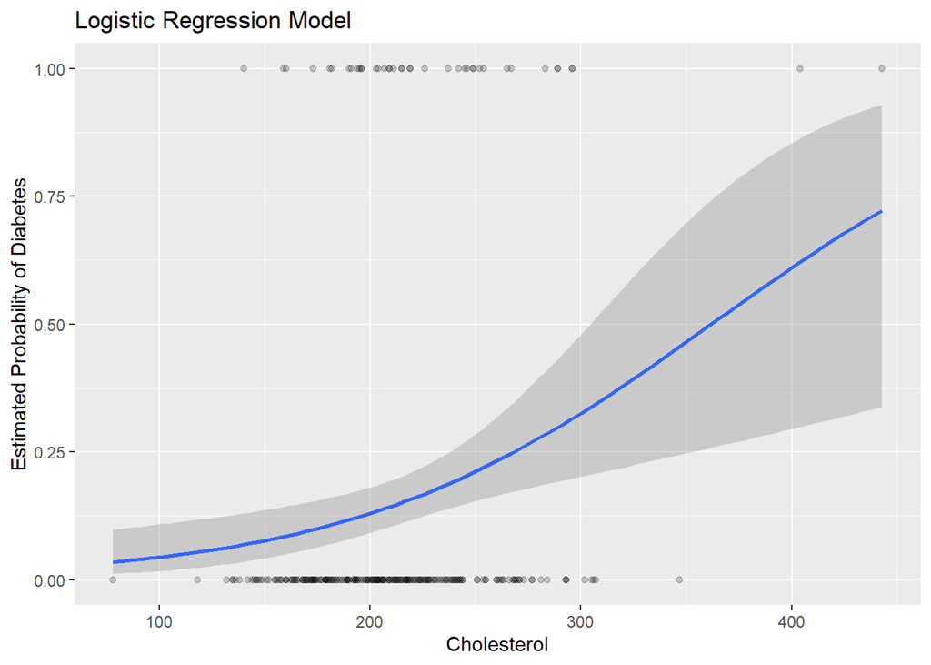

```r
no.na.train %>%
  mutate(prob = ifelse(has_diabetes == TRUE,1,0)) %>%
  ggplot(aes(chol,prob)) +
  geom_point(alpha =0.2) +
  geom_smooth(method = "glm", method.args = list(family = "binomial")) +
  labs(
    title = "Logistic Regression Model",
    x = "Cholesterol",
    y = "Estimated Probability of Diabetes"
  )
```

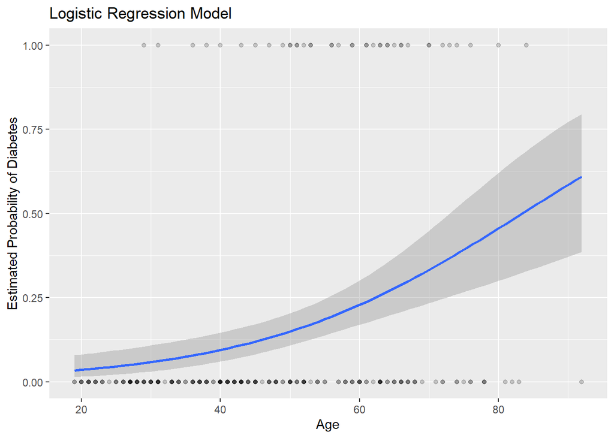

```r
no.na.train %>%
  mutate(prob = ifelse(has_diabetes == TRUE,1,0)) %>%
  ggplot(aes(age,prob)) +
  geom_point(alpha =0.2) +
  geom_smooth(method = "glm", method.args = list(family = "binomial")) +
  labs(
    title = "Logistic Regression Model",
    x = "Age",
    y = "Estimated Probability of Diabetes"
  )
```

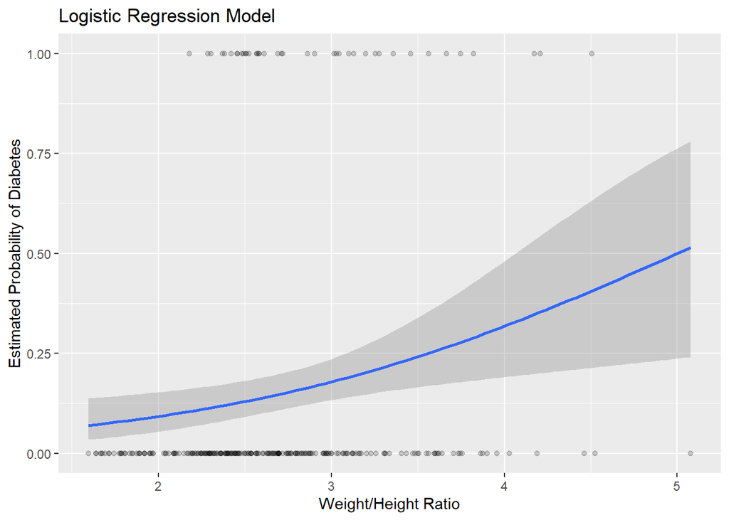

```r
no.na.train %>%
  mutate(prob = ifelse(has_diabetes == TRUE,1,0)) %>%
  ggplot(aes(weight_height_ratio,prob)) +
  geom_point(alpha =0.2) +
  geom_smooth(method = "glm", method.args = list(family = "binomial")) +
  labs(
    title = "Logistic Regression Model",
    x = "Weight/Height Ratio",
    y = "Estimated Probability of Diabetes"
  )
```

The plots give the estimated probability of diabetes with respect to each variable.

## Effect of Missing values

If we fit the model to the original train data with 20% of the data removed, we obtain a slightly different model.

```r
set.seed(123)
dt = sort(sample(nrow(no.na.train), nrow(no.na.train)*.8))
missing_train<-data[dt,]
logistic_model_missing <- glm(has_diabetes ~ stab.glu + chol + age + weight_height_ratio, data = missing_train, family = binomial)
summary(logistic_model_missing)
```

```
##
## Call:
## glm(formula = has_diabetes ~ stab.glu + chol + age + weight_height_ratio,
##     family = binomial, data = missing_train)
##
## Deviance Residuals:
##      Min        1Q    Median        3Q       Max
## -2.97878  -0.30279  -0.18330  -0.08314   2.30095
##
## Coefficients:
##                       Estimate Std. Error z value Pr(>|z|)
## (Intercept)         -13.859963   2.612930  -5.304 1.13e-07 ***
## stab.glu              0.027188   0.005360   5.072 3.93e-07 ***
## chol                  0.009161   0.006171   1.484  0.13768
## age                   0.062201   0.020903   2.976  0.00292 **
## weight_height_ratio   1.127189   0.448114   2.515  0.01189 *
## ---
## Signif. codes:  0 '***' 0.001 '**' 0.01 '*' 0.05 '.' 0.1 ' ' 1
##
## (Dispersion parameter for binomial family taken to be 1)
##
##     Null deviance: 179.148  on 199  degrees of freedom
## Residual deviance:  85.018  on 195  degrees of freedom
##   (5 observations deleted due to missingness)
## AIC: 95.018
##
## Number of Fisher Scoring iterations: 6
```

If we randomly remove the data we see that the fit is improved. This makes sense because there is less variation, and the model fit can be better fit to the data. However, this does not actually mean that the model is better, only that it is a better fit for the data.

```r
probabilities_missing <- logistic_model_missing %>% predict(no.na.test, type = "response")
head(probabilities_missing)
```

```
##           1           3           6          12          15          17
## 0.008926531 0.282563498 0.019819403 0.094753660 0.008040711 0.042301993
```

```r
predicted.classes.missing <- ifelse(probabilities_missing > 0.10, TRUE, FALSE)
mean(predicted.classes.missing == no.na.test$has_diabetes)
```

```
## [1] 0.7981651
```

```r
mean(predicted.classes.missing == no.na.test$has_diabetes & no.na.test$has_diabetes == TRUE)/mean(no.na.test$has_diabetes == TRUE)
```

```
## [1] 0.75
```